# STA 4102 Project

Emily Mendez

## Summary of Data

This Dataset is taken from the City of San Jose Department of Transportation Website. This data describes the crashes that occurred in the city from 2021 to present day; last updated on October 24, 2022, 1:45 AM (UTC-04:00). Variables listed include but are not limited to sex, Age, vehicle count,Sobriety, Fatal injuries, weather collision type, etc. Most of this data is qualitative, categorical data. The question we will be asking is whether we can predict which the highest type of injury a crash will cause

We will be using a XGBoost and a decision tree.

## Preparing Data

**Importing data**

```r
VehicleData=read.csv('/Users/admin/Documents/Csvv/Project_Data/vehiclecrashdata2021-present.csv',
                   header=TRUE,na.strings=c("","Unknown","Not Applicable"),stringsAsFactors = T)

CrashData=read.csv('/Users/admin/Documents/Csvv/Project_Data/crashdata2021-present.csv',
                  header=TRUE,na.strings=c("","Unknown","Not Applicable"),stringsAsFactors = T)
```

**Loading Libraries**

```r
library(caret)
library(dplyr)
library(xgboost)
library(pROC)
```

**Joining the DataSets**

```r
JoinedData=merge(VehicleData,CrashData,
           by="CrashName",all=TRUE)
str(JoinedData)
```

```
## 'data.frame':    15942 obs. of  39 variables:
##  $ CrashName                 : Factor w/ 7741 levels "CR-0000085197",..: 1 1 2 2 2 2 2 3 3 4 ...
##  $ Name                      : Factor w/ 15936 levels "ACV-0000174389",..: 1 2 3 4 5 6 7 8 9 10 ...
##  $ Sex                       : Factor w/ 2 levels "F","M": 2 NA 2 NA NA NA NA NA NA NA ...
##  $ Age                       : int  33 0 19 0 0 0 0 0 0 0 ...
##  $ Speed                     : logi  NA NA NA NA NA NA ...
##  $ VehicleDamage             : Factor w/ 5 levels "Major","Minor",..: NA NA 1 3 3 3 3 NA 1 NA ...
##  $ PartyCategory             : Factor w/ 5 levels "Bicycle","Driver",..: 2 2 2 4 4 4 4 2 4 2 ...
##  $ Sobriety                  : Factor w/ 8 levels "Had Been Drinking - Impairment Unknown",..: 5 5 4 NA NA NA NA 5 NA 5 ...
##  $ VehicleDirection          : Factor w/ 4 levels "East","North",..: 4 4 1 NA NA NA NA 3 NA 4 ...
##  $ MovementPrecedingCollision: Factor w/ 21 levels "Backing","Changing Lanes",..: 20 6 16 13 13 13 13 12 13 1 ...
##  $ PartyType                 : Factor w/ 18 levels "Bicycle","Bus - Other",..: 4 4 4 4 4 4 4 4 4 4 ...
##  $ OtherAssociatedFactor     : Factor w/ 50 levels "Defective Vehicle Equipment",..: NA NA 39 NA NA NA NA NA NA 22 ...
##  $ VehicleCount              : int  1 1 1 1 1 1 1 1 1 1 ...
##  $ ViolationCode             : int  NA NA 23103 NA NA NA NA NA NA NA ...
```

[output cut: 25 more lines]

```r
#Lots of Na values seen
head(JoinedData)
```

```
##       CrashName           Name  Sex Age Speed VehicleDamage PartyCategory
## 1 CR-0000085197 ACV-0000174389    M  33    NA          <NA>        Driver
## 2 CR-0000085197 ACV-0000174390 <NA>   0    NA          <NA>        Driver
## 3 CR-0000085218 ACV-0000174429    M  19    NA         Major        Driver
## 4 CR-0000085218 ACV-0000174430 <NA>   0    NA      Moderate        Parked
## 5 CR-0000085218 ACV-0000174431 <NA>   0    NA      Moderate        Parked
## 6 CR-0000085218 ACV-0000174432 <NA>   0    NA      Moderate        Parked
##                Sobriety VehicleDirection MovementPrecedingCollision PartyType
## 1  Impairment Not Known             West                    Stopped       Car
## 2  Impairment Not Known             West          Making Right Turn       Car
## 3 Had Not Been Drinking             East        Proceeding Straight       Car
## 4                  <NA>             <NA>                     Parked       Car
## 5                  <NA>             <NA>                     Parked       Car
## 6                  <NA>             <NA>                     Parked       Car
##   OtherAssociatedFactor VehicleCount ViolationCode ViolationCodeDescription
```

[output cut: 55 more lines]

**NA Values**

```r
#Which columns are the NA values in
colSums(is.na(JoinedData))
```

```
##                  CrashName                       Name
##                          0                          6
##                        Sex                        Age
##                       4566                          6
##                      Speed              VehicleDamage
##                      15942                       5004
##              PartyCategory                   Sobriety
##                         41                       2439
##           VehicleDirection MovementPrecedingCollision
##                       3608                        441
##                  PartyType      OtherAssociatedFactor
##                        789                       4511
##               VehicleCount              ViolationCode
##                          6                      10013
##   ViolationCodeDescription                CrashFactId
##                      10013                          0
##              MinorInjuries           ModerateInjuries
##                          0                          0
##             SevereInjuries              FatalInjuries
##                          0                          0
##                  TcrNumber             CityDamageFlag
##                          0                          0
##              ShortFormFlag                   Distance
##                          0                       1138
##              CrashDateTime           PedestrianAction
##                          0                         12
##             RoadwaySurface           RoadwayCondition
##                       1445                       1707
##                   Lighting     PrimaryCollisionFactor
##                        633                       3291
##             TrafficControl                    Weather
##                       1966                       1412
##              CollisionType    ProximityToIntersection
##                          0                          0
##        VehicleInvolvedWith    PedestrianDirectionFrom
##                         64                      15102
##      PedestrianDirectionTo  DirectionFromIntersection
##                      15094                        295
##                    Comment
##                      13220
```

**Removing un-neededcolumns and NAs**

```r
#To remove name, Speed,ViolationCode,CrashFactID,TcrNumber,ShortFromFlag ,distance, and comments category
#removing Pedestrian Direction, Traffic control , vehicle count only has 1 level
#removing age due to high Age == 0 considered NA value.
JoinedDataNoColNa=JoinedData[,-c(2,4,5,12,13,14,15,16,21,23,24,25,36,37,39)]

#removing
colSums(is.na(JoinedDataNoColNa))
```

```
##                  CrashName                        Sex
##                          0                       4566
##              VehicleDamage              PartyCategory
##                       5004                         41
##                   Sobriety           VehicleDirection
##                       2439                       3608
## MovementPrecedingCollision                  PartyType
##                        441                        789
##              MinorInjuries           ModerateInjuries
##                          0                          0
##             SevereInjuries              FatalInjuries
##                          0                          0
##             CityDamageFlag           PedestrianAction
##                          0                         12
##             RoadwaySurface           RoadwayCondition
##                       1445                       1707
##                   Lighting     PrimaryCollisionFactor
##                        633                       3291
##             TrafficControl                    Weather
##                       1966                       1412
##              CollisionType    ProximityToIntersection
##                          0                          0
##        VehicleInvolvedWith  DirectionFromIntersection
##                         64                        295
```

```r
#removing Na rows
JoinedDataNoNa=na.omit(JoinedDataNoColNa)

#dimensions
dim(JoinedDataNoNa)
```

```
## [1] 7160   24
```

## Predict Whether The Accident Will have injuries In Original Na dataset

```r
#Implying at least 1 fatal injury per crash
FatalIn=length(which(JoinedData$FatalInjuries>0))

#Implying at least 1 severe injury per crash
SevereIn=length(which(JoinedData$SevereInjuries>0))

#Implying at least 1 moderate injury per crash
ModerateIn=length(which(JoinedData$ModerateInjuries>0))

#Implying at least 1 minor injury per crash
MinorIn=length(which(JoinedData$MinorInjuries>0))
```

```r
#Total number of crashes in our dataset
TotCrashes=length(JoinedData$CrashName)

#percentages
CountFat=FatalIn/TotCrashes
CountSev=SevereIn/TotCrashes
CountMod=ModerateIn/TotCrashes
CountMin=MinorIn/TotCrashes

print(paste("The probability that at least 1 fatal injury will occur in this data set is",
            round(CountFat,3)*100,"%"))
```

```
## [1] "The probability that at least 1 fatal injury will occur in this data set is 1.4 %"
```

```r
print(paste("The probability that at least 1 severe injury will occur in this data set is",
            round(CountSev,3)*100,"%"))
```

```
## [1] "The probability that at least 1 severe injury will occur in this data set is 4.2 %"
```

```r
print(paste("The probability that at least 1 moderate injury will occur in this data set is",
            round(CountMod,3)*100,"%"))
```

```
## [1] "The probability that at least 1 moderate injury will occur in this data set is 15.9 %"
```

```r
print(paste("The probability that at least 1 minor injury will occur in this data set is",
            round(CountMin,3)*100,"%"))
```

```
## [1] "The probability that at least 1 minor injury will occur in this data set is 33.3 %"
```

Not many fatal accidents are given in this dataset compared to the number of accidents the dataset has. It doesnt feel meaningful enough to predict the fatalities in a crash. Instead we can predict the highest type of injury a crash will cause.

```r
#Implying that the probability of being in a crash where there will be at least 1 kind of injury

RowFatal=which(JoinedData$FatalInjuries>0)
RowSevere=which(JoinedData$SevereInjuries>0)
RowModerate=which(JoinedData$ModerateInjuries>0)
RowMinor=which(JoinedData$MinorInjuries>0)

#Number of crashes with at least 1 type of crash injury
temp=c(RowFatal,RowSevere,RowModerate,RowMinor)
JoinedDataMod=JoinedData[temp,]
TotCrash1Inj=length(JoinedDataMod$CrashName)


TotalInjury=TotCrash1Inj/TotCrashes
print(paste("The probability that at least 1 injury will occur in the NaDataSet is",
            round(TotalInjury,3)*100,"%"))
```

```
## [1] "The probability that at least 1 injury will occur in the NaDataSet is 54.7 %"
```

## Predict Whether The Accident Will have injuries NoNa Dataset

This Dataset is $\approx 45 \%$ of the number of observations in the Na Dataset

```r
#Implying at least 1 fatal injury per crash
FatalInNN=length(which(JoinedDataNoNa$FatalInjuries>0))

#Implying at least 1 severe injury per crash
SevereInNN=length(which(JoinedDataNoNa$SevereInjuries>0))

#Implying at least 1 moderate injury per crash
ModerateInNN=length(which(JoinedDataNoNa$ModerateInjuries>0))

#Implying at least 1 minor injury per crash
MinorInNN=length(which(JoinedDataNoNa$MinorInjuries>0))
```

```r
#Total number of crashes in our dataset
TotCrashesN=length(JoinedDataNoNa$CrashName)

#percentages
CountFatN=FatalInNN/TotCrashesN
CountSevN=SevereInNN/TotCrashesN
CountModN=ModerateInNN/TotCrashesN
CountMinN=MinorInNN/TotCrashesN

print(paste("The probability that at least 1 fatal injury will occur in this data set is",
            round(CountFatN,3)*100,"%"))
```

```
## [1] "The probability that at least 1 fatal injury will occur in this data set is 0.9 %"
```

```r
print(paste("The probability that at least 1 severe injury will occur in this data set is",
            round(CountSevN,3)*100,"%"))
```

```
## [1] "The probability that at least 1 severe injury will occur in this data set is 5.5 %"
```

```r
print(paste("The probability that at least 1 moderate injury will occur in this data set is",
            round(CountModN,3)*100,"%"))
```

```
## [1] "The probability that at least 1 moderate injury will occur in this data set is 22.7 %"
```

```r
print(paste("The probability that at least 1 minor injury will occur in this data set is",
            round(CountMinN,3)*100,"%"))
```

```
## [1] "The probability that at least 1 minor injury will occur in this data set is 51.3 %"
```

```r
#Implying that the probability of being in a crash where there will be at least 1 kind of injury

RowFatalN=which(JoinedDataNoNa$FatalInjuries>0)
RowSevereN=which(JoinedDataNoNa$SevereInjuries>0)
RowModerateN=which(JoinedDataNoNa$ModerateInjuries>0)
RowMinorN=which(JoinedDataNoNa$MinorInjuries>0)

#Number of crashes with at least 1 type of crash injury
tempN=c(RowFatalN,RowSevereN,RowModerateN,RowMinorN)
JoinedDataNMod=JoinedDataNoNa[tempN,]
TotCrash1InjN=length(JoinedDataNMod$CrashName)


TotalInjuryN=TotCrash1InjN/TotCrashesN
print(paste("The probability that at least 1 injury will occur in the NoNaDataSet is",
            round(TotalInjuryN,3)*100,"%"))
```

```
## [1] "The probability that at least 1 injury will occur in the NoNaDataSet is 80.5 %"
```

## Lets Explore Injuries and Other Factors

Since we have a higher percentage of our accidents beinf minor we will explore the relationship of the number of minor injuries and various categorical variables.

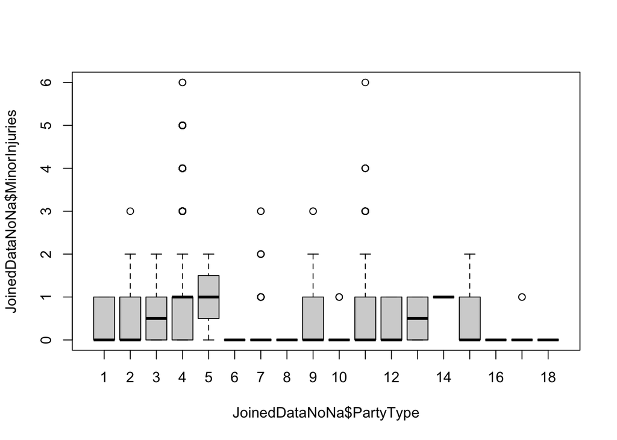

```r
boxplot(JoinedDataNoNa$MinorInjuries~JoinedDataNoNa$PartyType,names=c(1:length(levels(JoinedDataNoNa$PartyType))))
```

```r
levels(JoinedDataNoNa$PartyType)
```

```
##  [1] "Bicycle"                "Bus - Other"            "Bus - School"
##  [4] "Car"                    "Car With Trailer"       "Construction Equipment"
##  [7] "Emergency Vehicle"      "Light Rail Vehicle"     "Motorcycle/Moped"
## [10] "Other"                  "Panel Truck"            "Pedestrian"
## [13] "Scooter Motorized"      "Scooter Non-Motorized"  "Semi Truck"
## [16] "Skateboard"             "Train"                  "Wheelchair"
```

There doesn’t seem to be any significant difference here except that a car with a trailer might end up having more minor injuries than other levels. Though there are quite a bit of outliers on this graph.

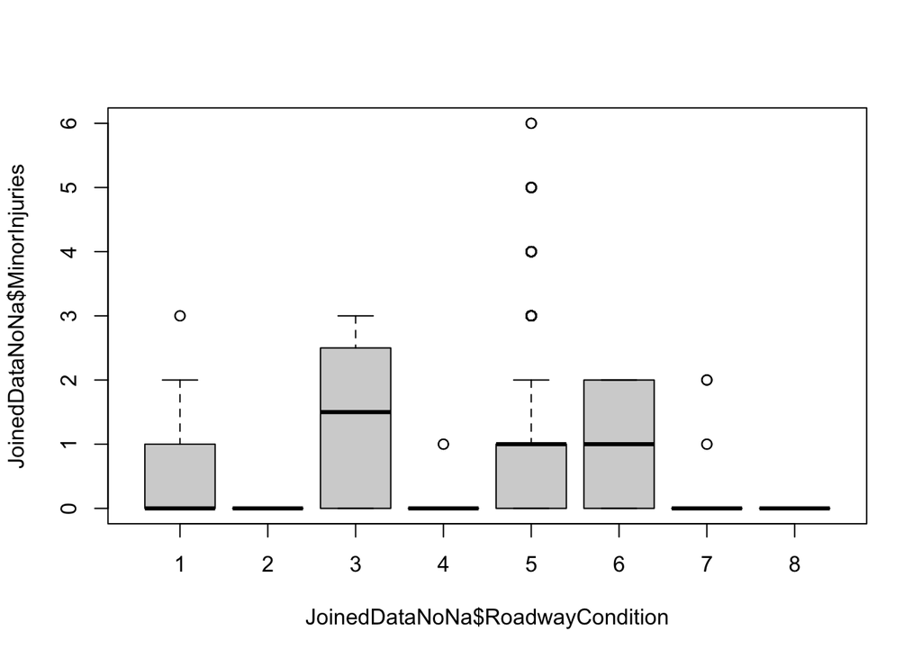

```r
boxplot(JoinedDataNoNa$MinorInjuries~JoinedDataNoNa$RoadwayCondition,names=c(1:8))
```

```r
levels(JoinedDataNoNa$RoadwayCondition)
```

```
## [1] "Construction - Repair Zone" "Flooded"
## [3] "Holes Deep Rut"             "Loose Material On Roadway"
## [5] "No Unusual Conditions"      "Obstruction On Roadway"
## [7] "Other"                      "Reduced Roadway Width"
```

```r
length(levels(JoinedDataNoNa$RoadwayCondition))
```

```
## [1] 8
```

More people get minor accidents from Deep rut holes than other levels of roadway conditions.

## Response Column

Creating a new categorical column where 0 is no injury, 1 is a minor injury, 2 is a moderate injury, 3 is a severe injury and 4 is a fatal injury. We categorize our new column by finding the number of injuries in each category and using the highest level of injury as the injury type. Such as if we have 3 minor injuries and 1 fatal injury the highest injury type is a 4.

```r
#creating new column in Dataframe

NoNaFullCrashCol=
(JoinedDataNoNa %>%
  mutate(HighestInjuryType=
        case_when(
        FatalInjuries>0 ~ 4,
        SevereInjuries>0 ~3,
        ModerateInjuries>0 ~ 2,
        MinorInjuries>0 ~1,
        TRUE ~ 0)
        ,.keep=c("none")
        ))
```

## Data Factoring

```r
#removing 1st col
JoinedDataNoNa=JoinedDataNoNa[,-c(1,8,9,10,11)]
str(JoinedDataNoNa)
```

```
## 'data.frame':    7160 obs. of  19 variables:
##  $ Sex                       : Factor w/ 2 levels "F","M": 2 1 1 2 2 2 2 2 2 2 ...
##  $ VehicleDamage             : Factor w/ 5 levels "Major","Minor",..: 1 2 2 3 1 1 4 3 3 2 ...
##  $ PartyCategory             : Factor w/ 5 levels "Bicycle","Driver",..: 2 2 2 2 2 2 2 2 2 2 ...
##  $ Sobriety                  : Factor w/ 8 levels "Had Been Drinking - Impairment Unknown",..: 4 4 4 1 4 1 4 4 4 4 ...
##  $ VehicleDirection          : Factor w/ 4 levels "East","North",..: 1 1 3 4 1 4 3 1 1 1 ...
##  $ MovementPrecedingCollision: Factor w/ 21 levels "Backing","Changing Lanes",..: 16 4 16 5 16 16 16 16 16 16 ...
##  $ FatalInjuries             : int  0 0 0 0 0 0 0 0 0 0 ...
##  $ CityDamageFlag            : Factor w/ 2 levels "False","True": 1 1 1 1 1 1 1 1 1 1 ...
##  $ PedestrianAction          : Factor w/ 7 levels "Crossing - Not In Crosswalk",..: 5 5 5 5 5 5 1 5 5 5 ...
##  $ RoadwaySurface            : Factor w/ 4 levels "Dry","Slippery (Muddy Oily etc.)",..: 1 1 1 1 1 1 1 1 1 1 ...
##  $ RoadwayCondition          : Factor w/ 8 levels "Construction - Repair Zone",..: 5 5 5 5 5 5 5 5 5 5 ...
##  $ Lighting                  : Factor w/ 5 levels "Dark - No Street Light",..: 2 4 4 5 5 2 2 2 2 2 ...
##  $ PrimaryCollisionFactor    : Factor w/ 7 levels "Bike At Fault",..: 6 6 6 6 6 6 5 6 6 6 ...
##  $ TrafficControl            : Factor w/ 4 levels "Controls Functioning",..: 4 1 1 1 1 4 4 4 4 4 ...
##  $ Weather                   : Factor w/ 7 levels "Clear","Cloudy",..: 1 2 2 1 1 1 1 1 1 1 ...
##  $ CollisionType             : Factor w/ 9 levels "Broadside","Head On",..: 7 1 1 1 1 6 9 6 6 6 ...
##  $ ProximityToIntersection   : Factor w/ 4 levels "Driveway","Intersection",..: 3 3 3 2 2 4 3 3 3 3 ...
##  $ VehicleInvolvedWith       : Factor w/ 16 levels "Animal","Bike",..: 10 9 9 9 9 10 11 9 9 9 ...
##  $ DirectionFromIntersection : Factor w/ 5 levels "At","East Of",..: 5 4 4 1 1 5 3 2 2 2 ...
```

```r
#Transforming data
options("contrasts")
```

```
## $contrasts
##         unordered           ordered
## "contr.treatment"      "contr.poly"
```

```r
newData=model.matrix(~. ,data=JoinedDataNoNa )

NoNaFullCrashDataBC=as.data.frame(newData)
```

```r
#adding in response column

NoNaFullCrashData=cbind(NoNaFullCrashDataBC,NoNaFullCrashCol)
```

## Data Partitioning

```r
Crash.label=NoNaFullCrashData$HighestInjuryType
NoNaFullCrashData$HighestInjuryType=NULL
label=Crash.label
```

```r
nn=nrow(NoNaFullCrashData)
row=0.5
```

```r
trainingInd=sample(nn,floor(row*nn))
training.data=as.matrix(NoNaFullCrashData[trainingInd,])
training.labels=label[trainingInd]
```

```r
testing.data=as.matrix(NoNaFullCrashData[-trainingInd,])
testing.labels=label[-trainingInd]
```

```r
xgb.train = xgb.DMatrix(data=training.data,label=training.labels)
xgb.test = xgb.DMatrix(data=testing.data,label=testing.labels)
```

```r
numClass=length(levels(as.factor(label)))
param=list("objective" = "multi:softmax", eta=0.05, subsample=0.5, max_depth=4)
```

```r
#fitting XGboost
xgb.fit = xgb.train( params=param, data=xgb.train,nrounds=500,num_class=5,
                     watchlist=list(val1=xgb.train,val2=xgb.test),
                     verbose=0 )
```

```r
xgb.pred = predict(xgb.fit,newdata=testing.data,reshape=T,type="response")
```

```r
confusionMatrix(table(xgb.pred,testing.labels))
```

```
## Confusion Matrix and Statistics
##
##         testing.labels
## xgb.pred    0    1    2    3    4
##        0  553  268  146   29    0
##        1  442 1139  447   87    0
##        2   46  122  155   52    0
##        3    7   11   24   25    0
##        4    0    0    0    0   27
##
## Overall Statistics
##
##                Accuracy : 0.5304
##                  95% CI : (0.5139, 0.5469)
##     No Information Rate : 0.4302
##     P-Value [Acc > NIR] : < 2.2e-16
##
##                   Kappa : 0.2672
##
##  Mcnemar's Test P-Value : NA
##
## Statistics by Class:
##
##                      Class: 0 Class: 1 Class: 2 Class: 3 Class: 4
## Sensitivity            0.5277   0.7396   0.2008 0.129534 1.000000
## Specificity            0.8250   0.5216   0.9217 0.987600 1.000000
## Pos Pred Value         0.5552   0.5385   0.4133 0.373134 1.000000
## Neg Pred Value         0.8084   0.7263   0.8075 0.952178 1.000000
## Prevalence             0.2927   0.4302   0.2156 0.053911 0.007542
## Detection Rate         0.1545   0.3182   0.0433 0.006983 0.007542
## Detection Prevalence   0.2782   0.5908   0.1047 0.018715 0.007542
## Balanced Accuracy      0.6764   0.6306   0.5612 0.558567 1.000000
```

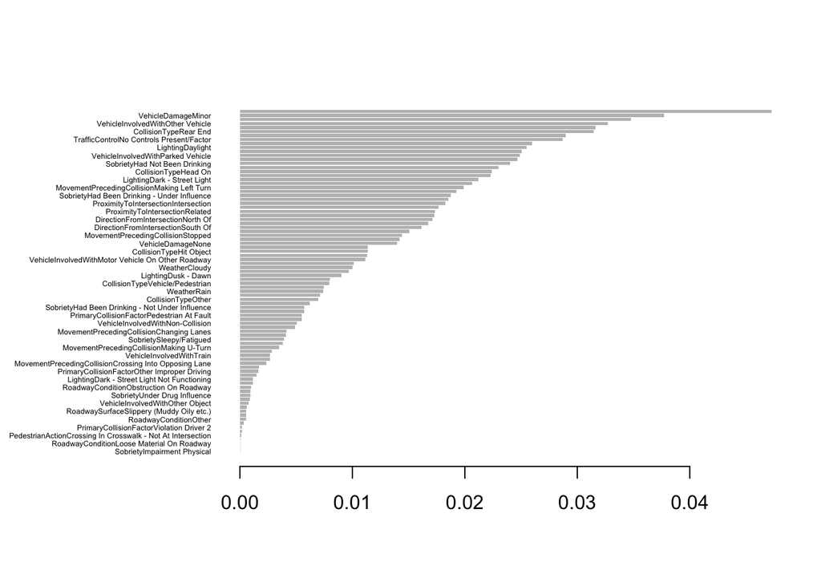

```r
#creating importiance plot
colNam=colnames(training.data)
importance= xgb.importance(colNam, model = xgb.fit)
xgb.plot.importance(importance)
```

```r
head(importance)
```

```
##                             Feature       Gain       Cover  Frequency
## 1:                    FatalInjuries 0.04728366 0.006187948 0.01117855
## 2:               VehicleDamageMinor 0.03769100 0.030449443 0.03301166
## 3:           CollisionTypeSideswipe 0.03476722 0.027539141 0.02235710
## 4: VehicleInvolvedWithOther Vehicle 0.03269521 0.015165219 0.02384175
## 5:            VehicleDamageModerate 0.03164282 0.026045146 0.03405965
## 6:            CollisionTypeRear End 0.03145937 0.024904579 0.02541374
##    Importance
## 1: 0.04728366
## 2: 0.03769100
## 3: 0.03476722
## 4: 0.03269521
## 5: 0.03164282
## 6: 0.03145937
```

```r
multiclass.roc(training.labels ,xgb.pred)
```

```
##
## Call:
## multiclass.roc.default(response = training.labels, predictor = xgb.pred)
##
## Data: xgb.pred with 5 levels of training.labels: 0, 1, 2, 3, 4.
## Multi-class area under the curve: 0.4979
```

```r
multiclass.roc(testing.labels ,xgb.pred)
```

```
##
## Call:
## multiclass.roc.default(response = testing.labels, predictor = xgb.pred)
##
## Data: xgb.pred with 5 levels of testing.labels: 0, 1, 2, 3, 4.
## Multi-class area under the curve: 0.7932
```

```r
library(tree)
library(rpart)
trainDF=JoinedDataNoNa[trainingInd,]
trainDF$HighestInjuryType=as.factor(training.labels)

testDF=JoinedDataNoNa[-trainingInd,]
testDF$HighestInjuryType=as.factor(testing.labels)
```

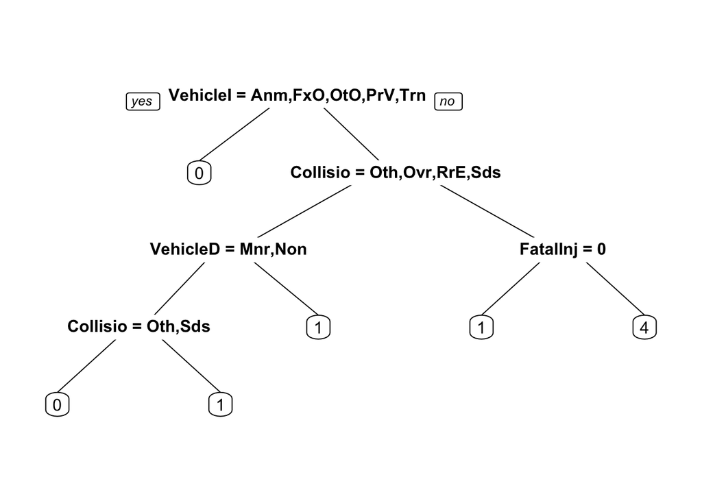

```r
DT.model1=rpart( HighestInjuryType~., data =trainDF)
rpart.plot::prp(DT.model1)
```

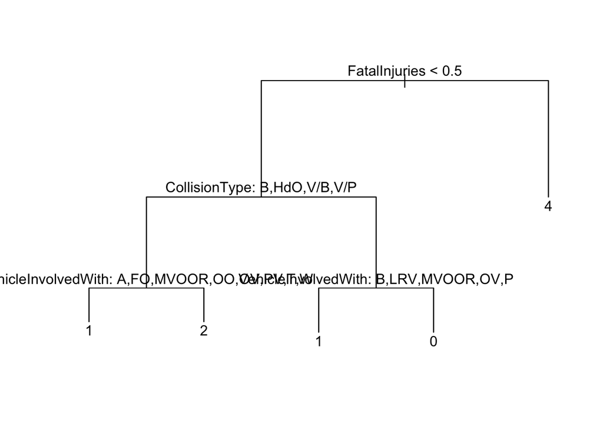

```r
tree.m1=tree(HighestInjuryType ~.  , data=trainDF)
plot(tree.m1)
text(tree.m1,pretty=1)
```

```r
Tree.CrashPred = predict(tree.m1, newdata=testDF,type="class")
```

```r
confusionMatrix(table(Tree.CrashPred,testDF$HighestInjuryType))
```

```
## Confusion Matrix and Statistics
##
##
## Tree.CrashPred    0    1    2    3    4
##              0  279   80  134   29    0
##              1  761 1358  512  100    0
##              2    8  102  126   64    0
##              3    0    0    0    0    0
##              4    0    0    0    0   27
##
## Overall Statistics
##
##                Accuracy : 0.5
##                  95% CI : (0.4835, 0.5165)
##     No Information Rate : 0.4302
##     P-Value [Acc > NIR] : < 2.2e-16
##
##                   Kappa : 0.1817
##
##  Mcnemar's Test P-Value : NA
##
## Statistics by Class:
##
##                      Class: 0 Class: 1 Class: 2 Class: 3 Class: 4
## Sensitivity           0.26622   0.8818   0.1632  0.00000 1.000000
## Specificity           0.90403   0.3270   0.9380  1.00000 1.000000
## Pos Pred Value        0.53448   0.4973   0.4200      NaN 1.000000
## Neg Pred Value        0.74853   0.7856   0.8030  0.94609 1.000000
## Prevalence            0.29274   0.4302   0.2156  0.05391 0.007542
## Detection Rate        0.07793   0.3793   0.0352  0.00000 0.007542
## Detection Prevalence  0.14581   0.7628   0.0838  0.00000 0.007542
## Balanced Accuracy     0.58512   0.6044   0.5506  0.50000 1.000000
```